# **Covid-19 Pandemic in Denmark**

Y.R.Wanigarathne

## Introduction

### Geography of Denmark

Denmark is a north european country which is located southwest of Sweden and due south of Norway and bordered by the Germany. Denmark has 1419 offshore islands and 1701 km of coastal line. Denmark has a total land area of 42,924 squarre kilometers while having population of 5.8 million.

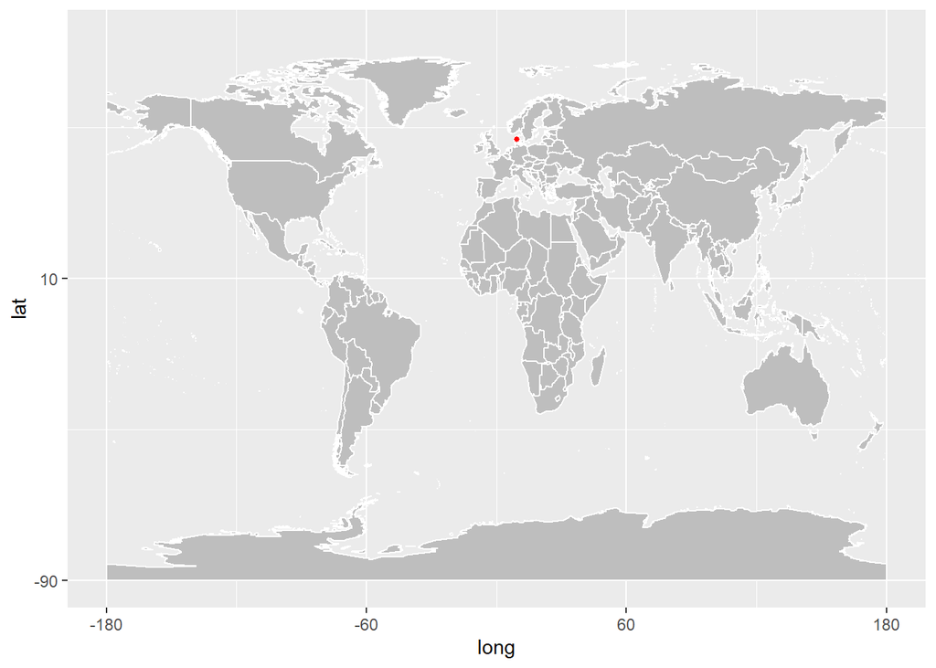

Geographical position of Denmark

### Climate of Denmark

People in Denmark experience temperate climate where the summers are relatively cool and winters are moderately cold. Denmark has a rainfall of 765mm per year. Summer of Denmark starts in June while the autumn starts in September. Winter of Denmark starts in December while the Spring starts in March.

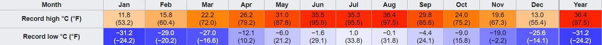

Highest and lowest termperaatures in Denmark (Source : https://en.wikipedia.org/wiki/Geography_of_Denmark)

### Political status of Denmark

Head of the state of the Denmark is Her excellency queen Magrethe II. Government is headed by prime minister her excellency Mrs.Mette Frederiksen. Currently Mr.Magnus Heunicke is appointed as the Miniter for Health and Elderly affairs.

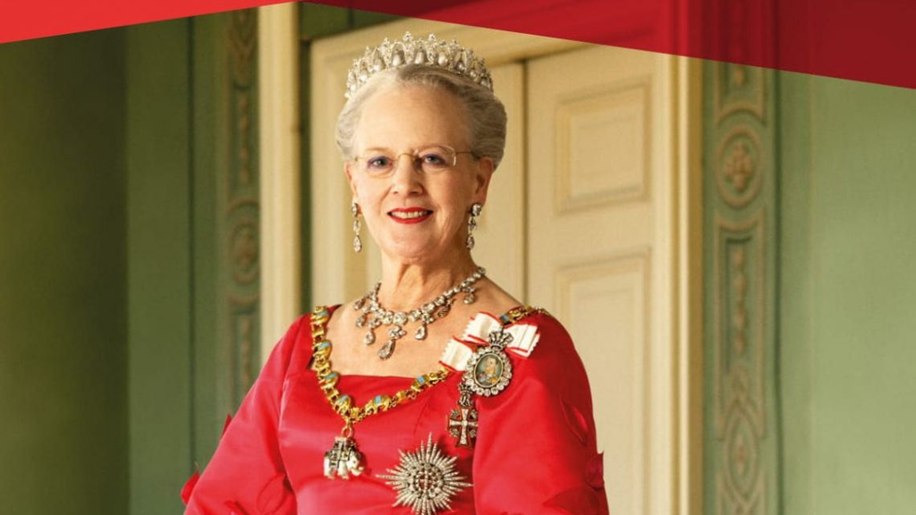

Queen Magrethe II (Source : https://www.batimes.com.ar/news/world/argentina-to-welcome-queen-margrethe-ii-of-denmark-next-week.phtml)

### Covid-19 status od Denmark

Lockdown of the Denmark started on 13th March 2020.All government workers engaged with non-essential work were ordered to stay home for two weeks while the government asked from private sector employers to allow their employees to stay home for the same period.New lockdown rules were imposed on 18th of March such as s hairdressers and nightclubs must be closed, restaurants can only serve take-away and no gatherings with more than 10 people. ON 23rd of March the government announced that the lockdown will be there for another 2 weeks until 13th of April. First phase of repopening of the country was happened on 15th April where the classes for students of 1-6 grades were started. Restaurants,cafes and hairdressers were reopened on 10th of May. This was not a fully reopen of the country where the rules like no larger gatherings were still in place.

## Exploratory data analysis

### Data analysis considering the cases of Denmark

Data can be analyzed considering the confirmed cases,death cases and recovered cases. Using the coronavirus dataset, the analysis was performed. The data were obtained from the period of 22nd of January to 12th of May.

##### 1.Confiremd cases

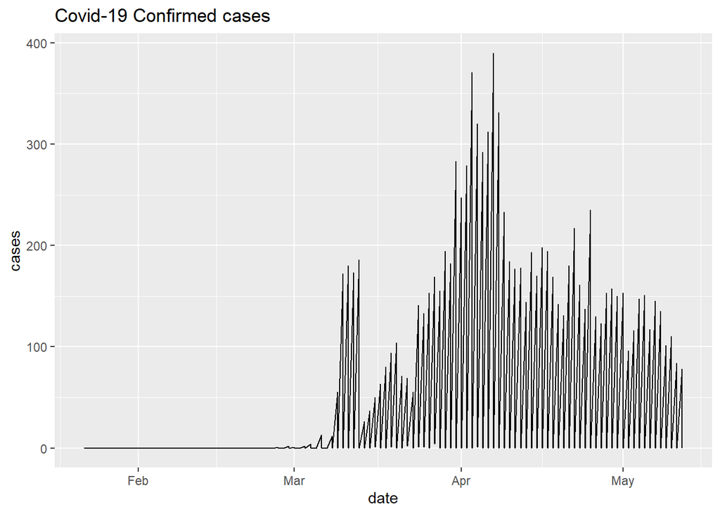

Using the above plot it can be seen that until the end of the February no confirmed case was reported. But in the 2nd week of March more than 150 cases per day reported.There was asignificant reduction of the confirmed cases in 3rd week of March. From 4th week of March to middle of 2nd week of April, the confirmed cases were significantly increased. On 7th of April the confirmed cases reached to the highest number recorded in Denmark to 391. As on the 1st week of may the confirmed cases were slowly decreased to a daily average of around 150 cases per day. On 12th of May, there were 78 confirmed cases reported.

##### 2.Recovered cases

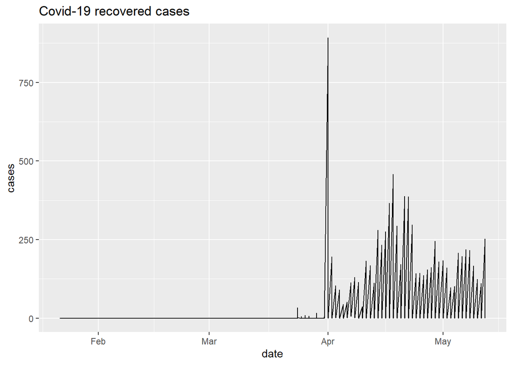

Using the above plot it can be seen that until the end of the March only few recovered cases were reported. But in the beginning of the 1st week of April the highest number of recoveries per day in Denmark of 894 recoveries were reported.Then there was a significant reduction of the recovered cases in the end of the 1st week to around 50 recoveries per day. From 2nd week of April to 4th week of April the recovered cases were significantly increased. On 18th of April 460 patients were recovered.From 4th week of April to 2nd week of May, there were around 150 recoveries per day on average.

##### 3. Death cases

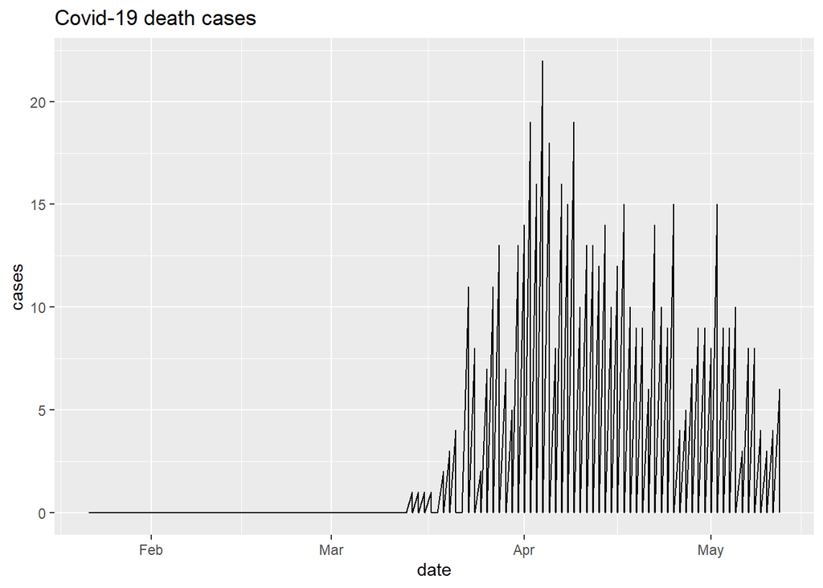

### Data analysis considering the cases of border countries

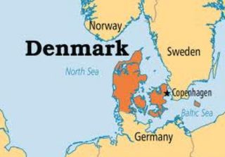

Border country map (Source : https://haraldgormssonbluetooth.weebly.com/denmark.html)

#### Germany VS Denmark

Confirmed cases,Recovered cases and death cases from Covid-19 in Germany and Denmark can be display as follows.

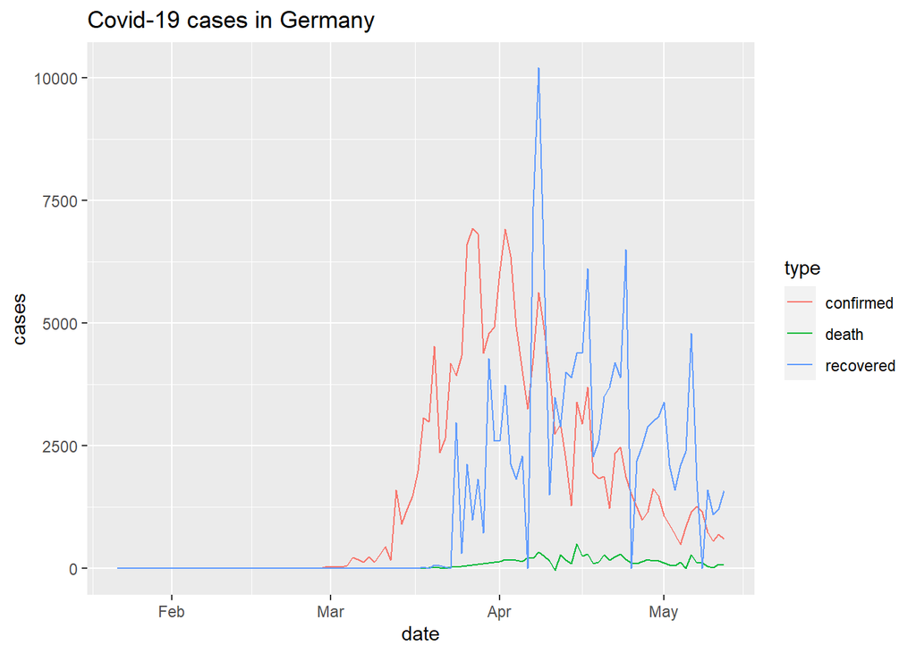